# Tarea 12

Mario Becerra 124362

20/04/2015

```r
library(ggplot2)
library(depmixS4)
library(plyr)
library(dplyr)
library(knitr)
```

# Ejercicio 1

Se uilizan los datos secuenciales del paquete *economics* del paquete ggplot2. Estos datos fueron producidos de series de tiempo económicas de EUA. Tiene 478 observaciones de 6 variables, siendo estas:

- *date*: fecha de la recolección del dato
- *pce*: gastos personales en consumo (en miles de millones de dólares)
- *pop*: población total (en miles)
- *psavert*: tasa de ahorro personal
- *uempmed*: mediana de duración de desempleo (en semanas)
- *unemploy*: número de desempleados (en miles)

```r
datos0 <- economics
kable(head(datos0))
```

| date | pce | pop | psavert | uempmed | unemploy |
| --- | --- | --- | --- | --- | --- |
| 1967-06-30 | 507.8 | 198712 | 9.8 | 4.5 | 2944 |
| 1967-07-31 | 510.9 | 198911 | 9.8 | 4.7 | 2945 |
| 1967-08-31 | 516.7 | 199113 | 9.0 | 4.6 | 2958 |
| 1967-09-30 | 513.3 | 199311 | 9.8 | 4.9 | 3143 |
| 1967-10-31 | 518.5 | 199498 | 9.7 | 4.7 | 3066 |
| 1967-11-30 | 526.2 | 199657 | 9.4 | 4.8 | 3018 |

Construimos ahora una nueva variable que represente la tasa de desempleo, *unemprate*, construida con el número de desempleados sobre la polación ($unemprate = \dfrac{unemploy}{pop}$).

```r
datos0$unemprate <- datos0$unemploy/datos0$pop
datos <- datos0[,c(-3,-6)]
kable(head(datos))
```

| date | pce | psavert | uempmed | unemprate |
| --- | --- | --- | --- | --- |
| 1967-06-30 | 507.8 | 9.8 | 4.5 | 0.0148154 |
| 1967-07-31 | 510.9 | 9.8 | 4.7 | 0.0148056 |
| 1967-08-31 | 516.7 | 9.0 | 4.6 | 0.0148559 |
| 1967-09-30 | 513.3 | 9.8 | 4.9 | 0.0157693 |
| 1967-10-31 | 518.5 | 9.7 | 4.7 | 0.0153686 |
| 1967-11-30 | 526.2 | 9.4 | 4.8 | 0.0151159 |

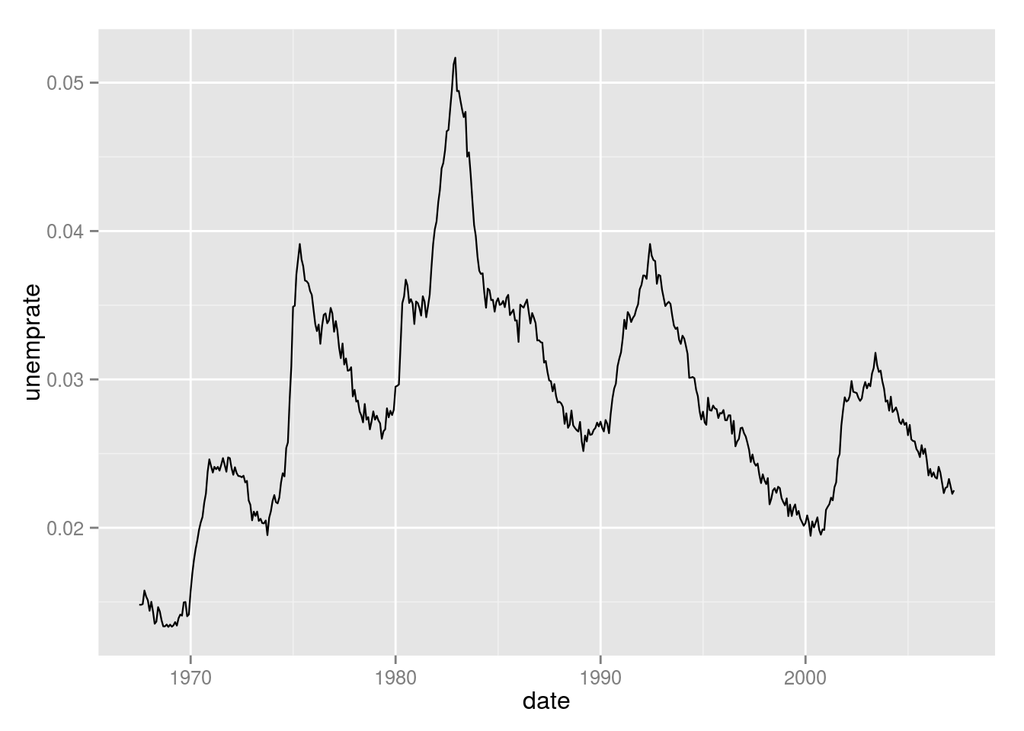

```r
ggplot(datos, aes(x = date, y = unemprate)) + geom_line(size=0.4)
```

Ahora, modelaremos la tasa de desempleo con un modelo de Markov oculto (HMM).

```r
modelos_hmm <- lapply(1:10, function(i) {
  mod_hmm <- depmix(unemprate~1, data=datos, nstates=i, family=gaussian())
  fit_hmm <- fit(mod_hmm, emcontrol = em.control(maxit = 200))
  fit_hmm
})

save(modelos_hmm, file='./Out/modelos_hmm.Rdata')
```

```r
load('./Out/modelos_hmm.Rdata')

df_temp <- data.frame(NumEstados=1:10, BIC=sapply(modelos_hmm, BIC), AIC=sapply(modelos_hmm, AIC))
kable(df_temp)
```

| NumEstados | BIC | AIC |
| --- | --- | --- |
| 1 | -3333.274 | -3341.613 |
| 2 | -3645.374 | -3674.561 |
| 3 | -4073.047 | -4131.421 |
| 4 | -4295.607 | -4391.508 |
| 5 | -4466.650 | -4608.417 |
| 6 | -4348.517 | -4544.489 |
| 7 | -4497.993 | -4756.508 |
| 8 | -4203.000 | -4532.400 |
| 9 | -4483.079 | -4891.701 |
| 10 | -4381.042 | -4877.226 |

```r
i=which(df_temp$BIC==min(df_temp$BIC))
mod <- modelos_hmm[[i]]
```

Elegimos el modelo con 7 estados ocultos, pues es el de menor BIC; y el AIC también es relativamente chico, aunque no es el menor.

Ahora realizamos simulaciones del modelo para realizar diagnósticos del ajuste del modelo

```r
class(mod) <- 'depmix'
set.seed(2805)
sims_1 <- simulate(mod, nsim = 19)
unemp_null <- data.frame(unemprate = sims_1@response[[1]][[1]]@y,
  date = rep(datos$date, 19)) %>%
  rbind(datos[,c(1,5)])
codigo <- sample(1:20)
unemp_null$tipo <- rep(codigo, each = nrow(datos))
head(unemp_null)
```

```
##    unemprate       date tipo
## 1 0.01326368 1967-06-30    2
## 2 0.01428985 1967-07-31    2
## 3 0.01312102 1967-08-31    2
## 4 0.01503050 1967-09-30    2
## 5 0.01501075 1967-10-31    2
## 6 0.02015796 1967-11-30    2
```

```r
tail(unemp_null)
```

```
##       unemprate       date tipo
## 9555 0.02269010 2006-10-31   19
## 9556 0.02274886 2006-11-30   19
## 9557 0.02328939 2006-12-31   19
## 9558 0.02277092 2007-01-31   19
## 9559 0.02228822 2007-02-28   19
## 9560 0.02252636 2007-03-31   19
```

Graficamos los datos reales junto con conjuntos de datos simulados.

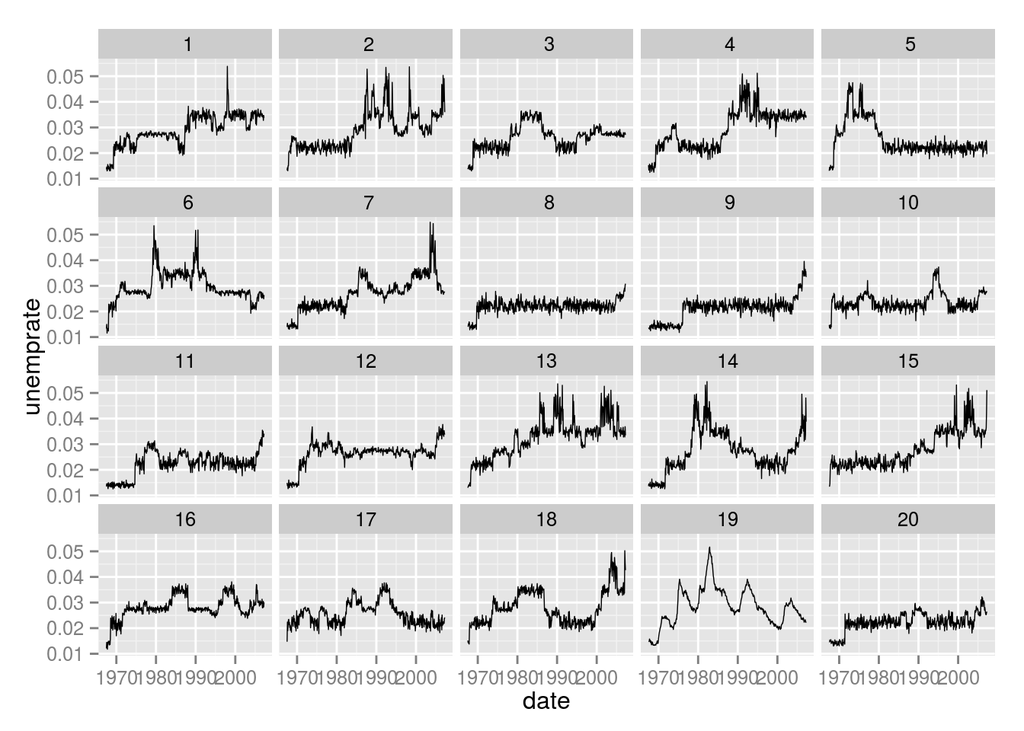

```r
ggplot(unemp_null, aes(x = date, y = unemprate)) +
  geom_line(size=0.25) +
  facet_wrap(~tipo)
```

Vemos que las autocorrelaciones de grado 1 son similares en las simulaciones.

```r
temp <- unemp_null %>%
  group_by(tipo) %>%
  mutate(rate_lag = lag(unemprate)) %>%
  filter(!is.na(rate_lag)) %>%
  summarise(cor = cor(unemprate, rate_lag))
kable(temp)
```

| tipo | cor |
| --- | --- |
| 1 | 0.9361376 |
| 2 | 0.8948516 |
| 3 | 0.9180698 |
| 4 | 0.9264843 |
| 5 | 0.9329759 |
| 6 | 0.9118420 |
| 7 | 0.9356377 |
| 8 | 0.6506270 |
| 9 | 0.8853354 |
| 10 | 0.8203883 |
| 11 | 0.9093490 |
| 12 | 0.9408480 |
| 13 | 0.8838179 |
| 14 | 0.9195266 |
| 15 | 0.8992911 |
| 16 | 0.9171692 |
| 17 | 0.8737150 |
| 18 | 0.9357067 |
| 19 | 0.9940936 |
| 20 | 0.8440558 |

E incluso podemos comparar las gráficas de autocorrelación:

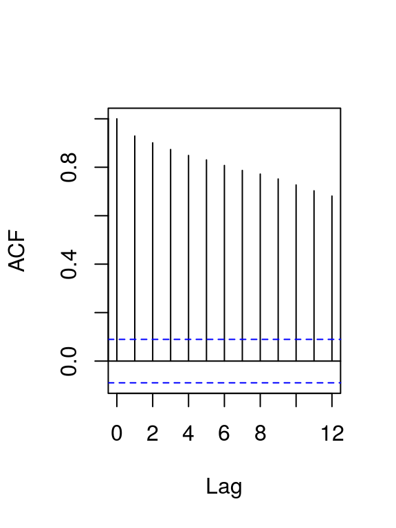

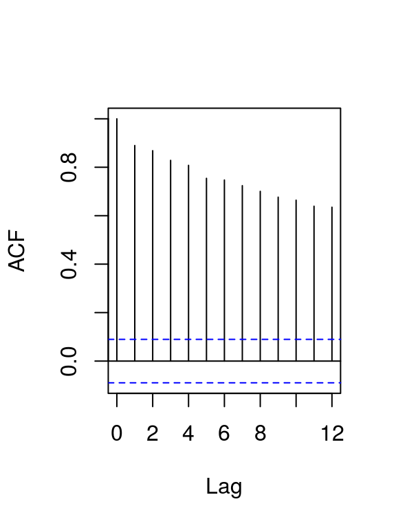

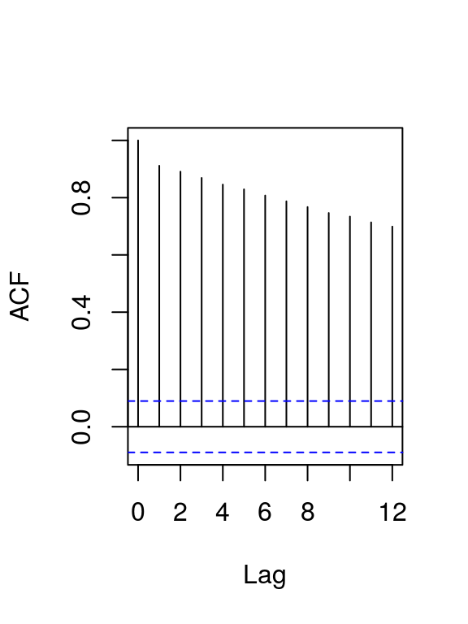

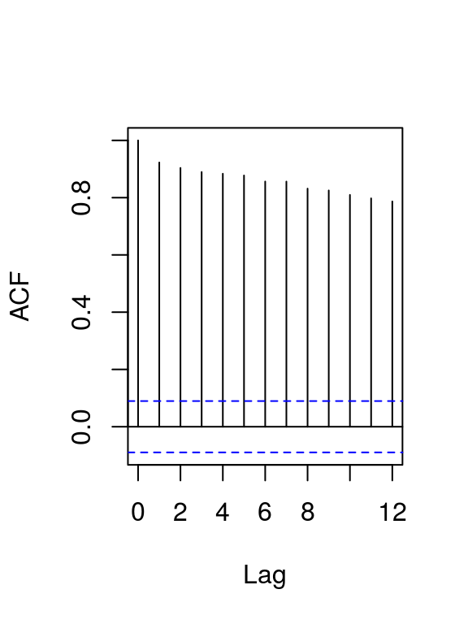

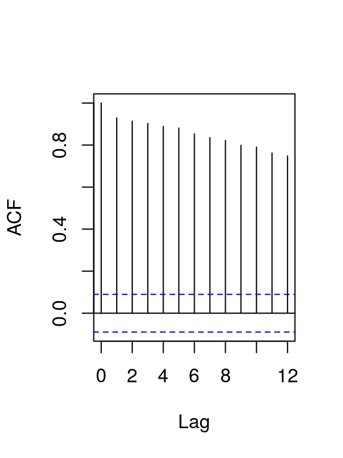

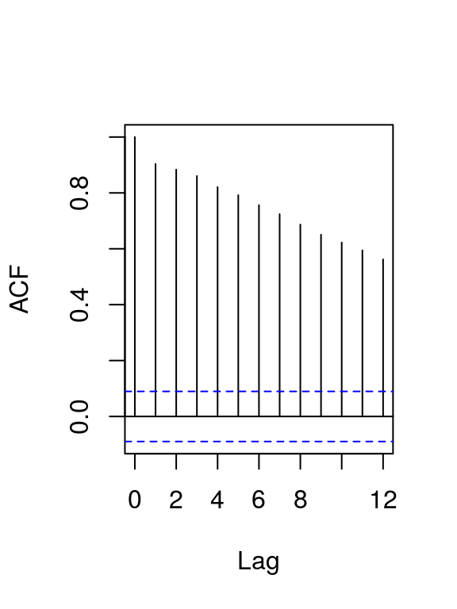

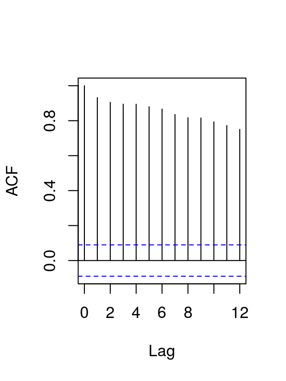

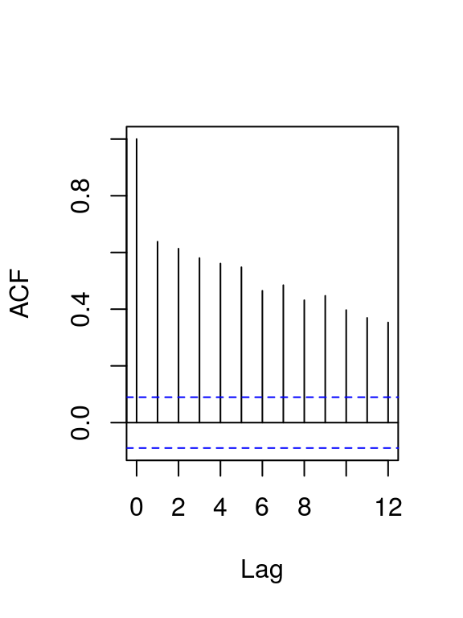

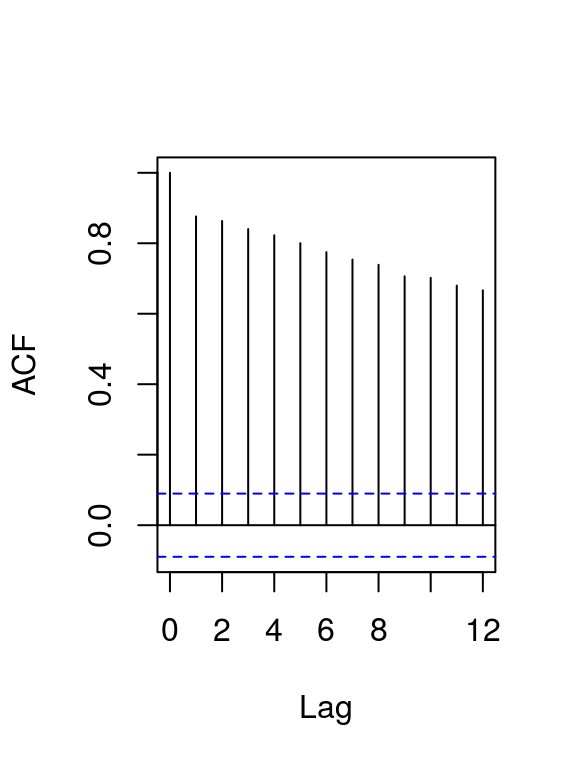

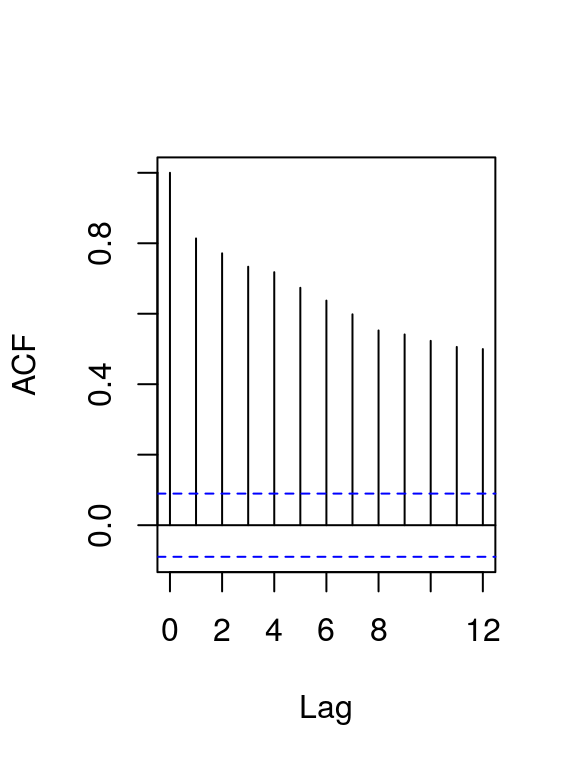

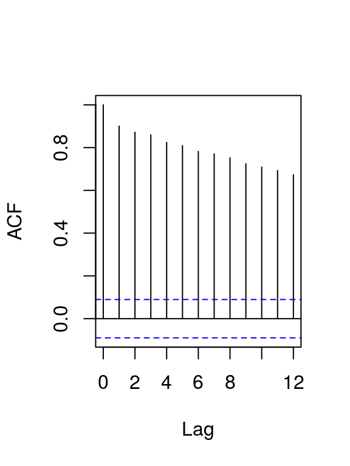

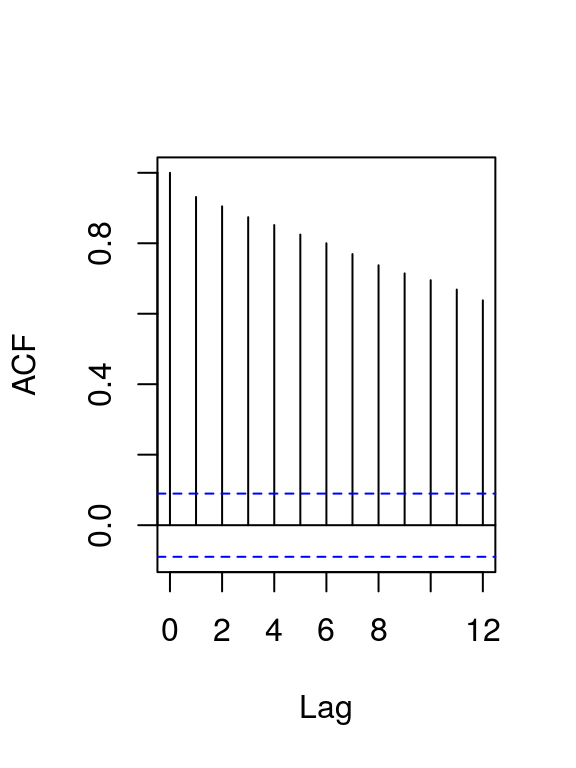

[8 more figures not shown]

```r
set.seed(1602)
sims_x <- ddply(unemp_null, 'tipo', function(df){
  x <- df$unemprate
  acf(x, lag.max=12, main="")
  x
})
```

Podemos ver el desempeño de estos modelos en predicción:

```r
set.seed(124362)
preds_2  <- sapply((nrow(datos)-20):(nrow(datos)-1) ,function(k){
  print(k)
  dat.1 <- datos[1:k,,drop=FALSE]
  mod.1 <- depmix(unemprate~1, data=datos, nstates=i, family=gaussian()) #unemprate~1
  fit.mod.1 <- fit(mod.1, verbose = FALSE, emcontrol=em.control(maxit=600))
  probs.1 <- fit.mod.1@posterior[k,2:4]
  estado.k <- which(probs.1==max(probs.1))
  estado.pred <- which.max(predict(fit.mod.1@transition[[estado.k]]))
  fit.mod.1@response[[estado.pred]][[1]]@parameters[1]$coefficients
})
save(preds_2, file='./Out/preds_2.Rdata')
```

```r
load('./Out/preds_2.Rdata')
EMA<-mean(abs(preds_2 - datos[(nrow(datos)-20):(nrow(datos)-1), "unemprate"]))
VA<-mean(abs(datos[(nrow(datos)-50):(nrow(datos)),"unemprate"] - datos[(nrow(datos)-51):(nrow(datos)-1),"unemprate"]))
EMA
```

```
## [1] 0.002654761
```

```r
VA
```

```
## [1] 0.0004875846
```

Error Medio Absoluto: $0.0026548$

Error de predicción de tomar el valor anterior: $4.8758461\times 10^{-4}$

# Ejercicio 2

Los datos conapo_2010.csv reportan el porcentaje de la población analfabeta, sin primaria terminada, sin drenaje, etc. En este ejercicio utilizaremos esta base de datos para construir un índice de carencias a nivel localidad.

```r
conapo <- read.csv('conapo_2010.csv', sep=' ')
kable(head(conapo))
```

| X | analfabeta | sin_primaria | sin_drenaje | sin_electricidad | sin_agua_entubada | con_hacinamiento | con_piso_tierra | habitantes_5000 | salarios_minimos | CVE_MUN | NOM_MUN | CVE |
| --- | --- | --- | --- | --- | --- | --- | --- | --- | --- | --- | --- | --- |
| 001 Aguascalientes | 2.59 | 11.48 | 0.49 | 0.31 | 0.77 | 25.25 | 1.42 | 8.73 | 29.90 | 1 | Aguascalientes | 1001 |
| 002 Asientos | 5.54 | 26.02 | 5.72 | 2.14 | 2.05 | 45.27 | 2.59 | 100.00 | 59.52 | 2 | Asientos | 1002 |
| 003 Calvillo | 6.19 | 28.88 | 0.79 | 0.87 | 1.80 | 39.79 | 2.42 | 50.76 | 60.08 | 3 | Calvillo | 1003 |
| 004 Cosío | 4.35 | 21.81 | 2.18 | 2.00 | 0.29 | 44.69 | 3.26 | 100.00 | 54.76 | 4 | Cosío | 1004 |
| 005 Jesús María | 3.76 | 18.21 | 1.26 | 1.17 | 1.43 | 39.16 | 2.59 | 45.17 | 31.15 | 5 | Jesús María | 1005 |
| 006 Pabellón de Arteaga | 4.11 | 18.74 | 0.94 | 0.98 | 1.45 | 41.38 | 1.54 | 31.60 | 36.30 | 6 | Pabellón de Arteaga | 1006 |

```r
pcacon<-prcomp(conapo[,c(-1,-11,-12,-13)])
expvar <- data.frame(comp=1:length(pcacon$sdev), varianza_explicada=(pcacon$sdev)^2 / sum(pcacon$sdev^2))
```

Varianza explicada por cada componente.

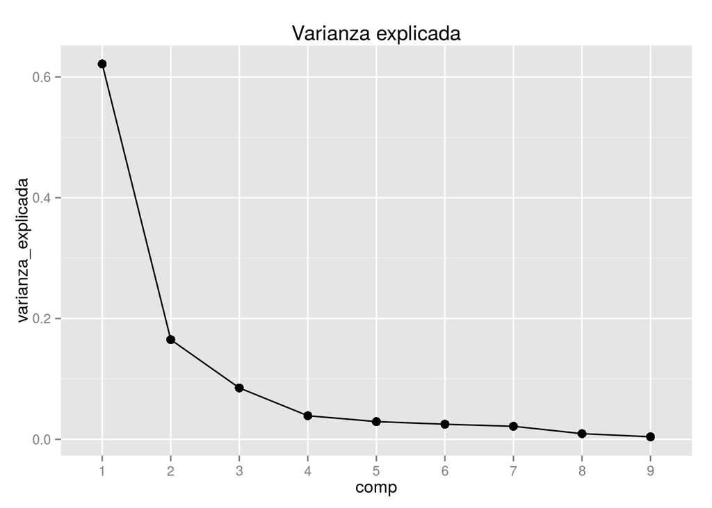

```r
ggplot(expvar, aes(x=comp, y=varianza_explicada))+geom_line()+geom_point(size=3)+ ggtitle("Varianza explicada") + scale_x_discrete(breaks = 1:length(pcacon$sdev))
```

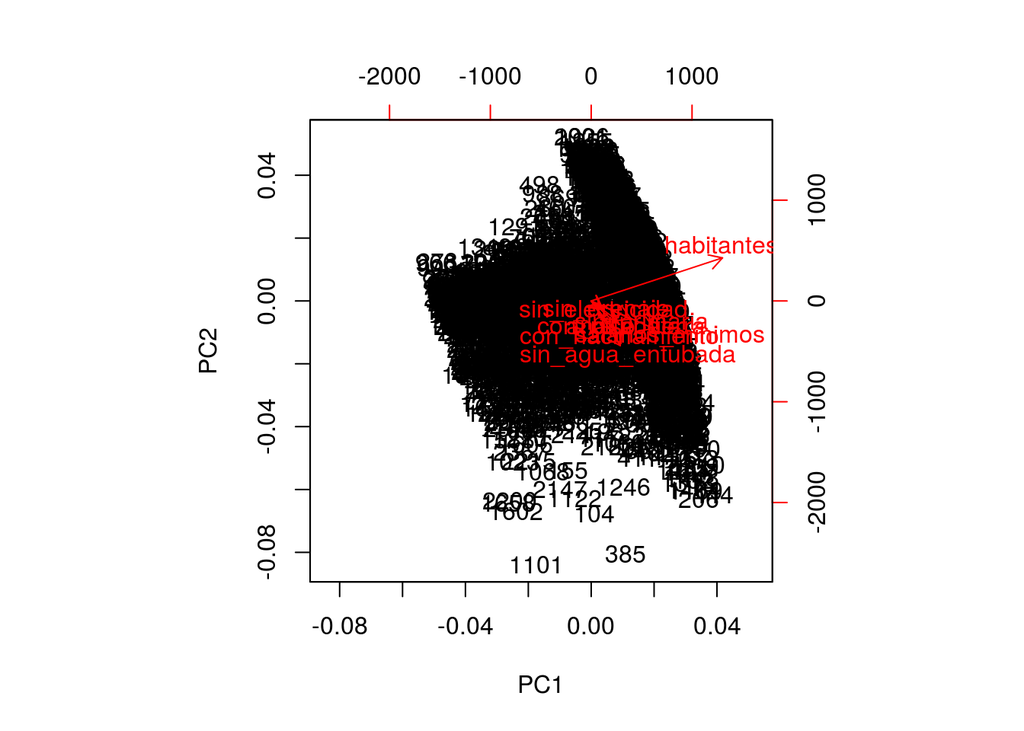

```r
biplot(pcacon)
```